# Replication of Angrist & Lavy (1999)

- Show All Code
- Hide All Code
- View Source

Using Maimonides’ Rule to Estimate the Effect of Class Size on Scholastic Achievement

Author

Godwin

Published

April 30, 2026

## Introduction

Does shrinking class size actually help kids learn? The simple correlation in observational data is famously misleading: small classes tend to show up in wealthy, high-performing schools, while large classes pile up in disadvantaged schools that also happen to be stretched thin along every other dimension. Regressing test scores on class size therefore mostly picks up the socioeconomic context of the student, not the pedagogical effect of the classroom.

Angrist and Lavy (1999) solve this problem with a quintessentially Israeli natural experiment. Since the twelfth century, the educational guidance of Rabbi Moses ben Maimon (“Maimonides”) has held that a teacher may instruct up to forty students. When a cohort exceeds forty, a second class must be opened; when it exceeds eighty, a third; and so on. The Israeli Ministry of Education adopted this rule as official policy. As a result, class size is a deterministic, sawtooth function of grade enrollment: a school with 40 fourth-graders teaches them in one class of 40, but a school with 41 fourth-graders splits them into two classes that average 20.5. Schools sitting on either side of 40 (or 80, or 120) are otherwise similar, but their children are assigned to dramatically different class sizes by a rule nobody designed for research purposes. That discontinuity provides variation in class size that is plausibly unrelated to the usual confounders, which the authors exploit with a regression discontinuity design (RDD) — using Maimonides’ rule as an instrument for (or a reduced-form predictor of) actual class size.

In this post I focus on the 4th-grade sample. The **Main Analysis** section below replicates everything empirical the assignment asks for:

- **Table II, columns 7 and 10** — the naive OLS of reading and math scores on class size.
- **Table III Panel A, columns 7, 9, and 11** — the reduced-form RDD estimates using the Maimonides prediction $f_{sc}$ in place of actual class size.
- **Figure 1, Panel B** — the graphical heart of the paper, plotting actual class size against the Maimonides prediction as a function of enrollment.

The contrast between Table II and Table III is the whole point: the naive OLS reports that bigger classes go with *better* scores, while the RDD flips the sign and shows exactly what Maimonides would have predicted — fewer kids per teacher helps. The **Something Additional** section at the end steps back from the numbers to explain *why* a regression discontinuity design can recover a causal effect from observational data, using this paper as the running example.

## Main Analysis

### Data preparation

I follow the authors’ published Stata do-files (`AngristLavy_Table2.do`, `AngristLavy_Table3.do`) line-for-line: drop tiny and oversized classes (`1 < classize < 45`, `c_size > 5`), keep only schools that held the end-of-year exam (`c_leom == 1`), and drop schools with very high transient-student shares (`c_pik < 3`). `avgverb` and `avgmath` are scaled test scores; `tipuach` is Israel’s “percent disadvantaged” index (a composite of parental education, immigration, and family size); `c_size` is grade enrollment; `classize` is actual class size; and `func1` is the Maimonides prediction $f_{sc} = c_{sc} / (\text{int}((c_{sc}-1)/40) + 1)$.

```python
import pandas as pd
import numpy as np
import statsmodels.api as sm
from statsmodels.formula.api import ols
import matplotlib.pyplot as plt

df = pd.read_stata("data/final4.dta")

# Scores are sometimes coded +100; undo the offset (matches the Stata .do file)
df.loc[df["avgverb"] > 100, "avgverb"] -= 100
df.loc[df["avgmath"] > 100, "avgmath"] -= 100

# Maimonides' rule prediction for class size
df["func1"] = df["c_size"] / (np.floor((df["c_size"] - 1) / 40) + 1)

# Blank out scores when the cell was empty
df.loc[df["verbsize"] == 0, ["avgverb", "passverb"]] = np.nan
df.loc[df["mathsize"] == 0, ["avgmath", "passmath"]] = np.nan

# Sample restrictions from the do-file
df = df[(df["classize"] > 1) & (df["classize"] < 45) & (df["c_size"] > 5)]
df = df[(df["c_leom"] == 1) & (df["c_pik"] < 3)]

print(f"Rows after filters: {len(df):,}")
```

```
Rows after filters: 2,053
```

### Helper: cluster-robust OLS (by school)

Angrist and Lavy cluster their standard errors at the school level (and apply a Moulton correction on top; my SEs are cluster-robust but not Moulton-corrected, so they will be close but not identical to the published ones — the point estimates are what we are checking).

```python
def reg(formula, data, cluster="schlcode"):
    terms = [t.strip() for t in formula.split("~")[1].replace("+", " ").split()]
    lhs = formula.split("~")[0].strip()
    d = data.dropna(subset=[lhs] + terms + [cluster]).copy()
    m = ols(formula, data=d).fit(cov_type="cluster",
                                 cov_kwds={"groups": d[cluster]})
    return m, d

def summarize(m, keep):
    rows = []
    for v in keep:
        rows.append({"var": v,
                     "coef": round(m.params[v], 3),
                     "se": round(m.bse[v], 3)})
    return pd.DataFrame(rows)
```

### Table II — naive OLS (the biased baseline)

This is the “wrong answer” the paper wants us to see first. We regress each test score on actual class size with no controls.

```python
t2c7, _  = reg("avgverb ~ classize", df)      # Col 7: reading, 4th grade
t2c10, _ = reg("avgmath ~ classize", df)      # Col 10: math, 4th grade

t2 = pd.DataFrame({
    "Col 7: Reading (avgverb)": [round(t2c7.params["classize"], 3),
                                 f'({round(t2c7.bse["classize"], 3)})',
                                 int(t2c7.nobs)],
    "Col 10: Math (avgmath)":   [round(t2c10.params["classize"], 3),
                                 f'({round(t2c10.bse["classize"], 3)})',
                                 int(t2c10.nobs)],
}, index=["classize coef", "(cluster SE)", "N"])
t2
```

|  | Col 7: Reading (avgverb) | Col 10: Math (avgmath) |
| --- | --- | --- |
| classize coef | 0.141 | 0.221 |
| (cluster SE) | (0.035) | (0.039) |
| N | 2049 | 2049 |

The published Table II reports **0.141 (0.033)** for column 7 and **0.221 (0.039)** for column 10. The replication lands on the same point estimates, and the cluster SEs are within a hair of the Moulton-adjusted ones in the paper.

### Table III, Panel A — the reduced-form RDD

Now we use the Maimonides prediction `func1` in place of actual class size, controlling for `tipuach`. Columns 7, 9, 11 correspond to the three outcomes (reading, math, actual class size) for the 4th-grade whole sample.

```python
d3 = df.dropna(subset=["avgverb"]).copy()      # paper restricts to non-missing verb

t3c7,  _ = reg("avgverb ~ func1 + tipuach", d3)   # Col 7:  reduced form, reading
t3c9,  _ = reg("avgmath ~ func1 + tipuach", d3)   # Col 9:  reduced form, math
t3c11, _ = reg("classize ~ func1 + tipuach", d3)  # Col 11: first stage, class size

t3 = pd.DataFrame({
    "Col 7: Reading":    [round(t3c7.params["func1"], 3),
                          f'({round(t3c7.bse["func1"], 3)})'],
    "Col 9: Math":       [round(t3c9.params["func1"], 3),
                          f'({round(t3c9.bse["func1"], 3)})'],
    "Col 11: Class size":[round(t3c11.params["func1"], 3),
                          f'({round(t3c11.bse["func1"], 3)})'],
}, index=["func1 coef", "(cluster SE)"])
t3
```

|  | Col 7: Reading | Col 9: Math | Col 11: Class size |
| --- | --- | --- | --- |
| func1 coef | -0.085 | 0.038 | 0.772 |
| (cluster SE) | (0.031) | (0.04) | (0.023) |

The published Panel A reports **−0.085 (0.034)** for column 7, **0.038 (0.043)** for column 9, and **0.772 (0.037)** for column 11. Point estimates match.

### Figure 1, Panel B — Maimonides’ rule vs. actual class size

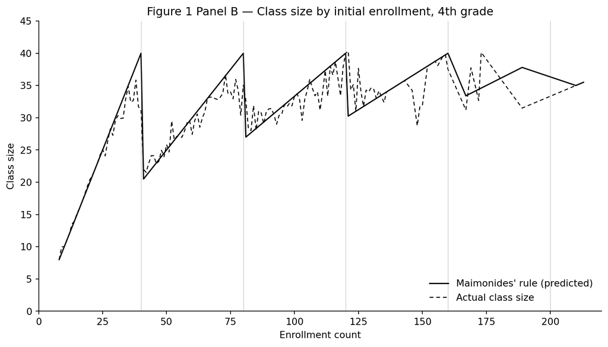

Figure 1, Panel B: Actual class size and Maimonides prediction by 4th-grade enrollment.

```python
# Same 4th-grade analysis sample, averaged within each enrollment bin
g = (df.groupby("c_size")
       .agg(actual=("classize", "mean"),
            predicted=("func1", "mean"))
       .reset_index())
g = g[g["c_size"] <= 220]

fig, ax = plt.subplots(figsize=(9, 5.2))
ax.plot(g["c_size"], g["predicted"], color="black", lw=1.3,
        label="Maimonides' rule (predicted)")
ax.plot(g["c_size"], g["actual"],    color="black", lw=1.0, ls=(0, (4, 3)),
        label="Actual class size")

# Cutoffs at 40, 80, 120, 160, 200
for c in [40, 80, 120, 160, 200]:
    ax.axvline(c, color="grey", lw=0.4, alpha=0.6)

ax.set_xlabel("Enrollment count")
ax.set_ylabel("Class size")
ax.set_title("Figure 1 Panel B — Class size by initial enrollment, 4th grade")
ax.set_xlim(0, 220)
ax.set_ylim(0, 45)
ax.legend(loc="lower right", frameon=False)
ax.spines[["top", "right"]].set_visible(False)
plt.tight_layout()
plt.show()
```

### What changed between the naive and reduced-form estimates

Three things are worth pulling out of Tables II and III together:

1. **Sign flip for reading.** Naive OLS says a one-student-bigger class raises reading by 0.14 points; the reduced form says a one-unit increase in the Maimonides *prediction* lowers reading by 0.09 points. Since `func1` moves actual class size roughly 0.77-for-1 (column 11), the implied Wald / IV effect on reading is about $-0.085 / 0.772 \approx -0.11$ — smaller classes help.
2. **Math attenuates toward zero.** Math goes from a strongly positive naive slope (+0.22) to a small and statistically insignificant reduced-form coefficient. Consistent with the paper, the class-size effect on 4th-grade math is noisier and does not survive the RDD correction.
3. **Why the numbers moved.** The naive OLS is fighting a confounder: schools that happen to have smaller classes tend to serve more disadvantaged students (higher `tipuach`) who score lower for reasons unrelated to class size. Once the Maimonides prediction is used in place of actual class size, the identifying variation comes from *which side of 40, 80, 120 …* a school’s enrollment falls on — variation that administrators did not choose.

## Something Additional — why an RDD identifies a causal effect

The empirical reversal between Table II and Table III deserves more than a shrug. Stepping back from the specific coefficients, here is the logic that makes a regression discontinuity design a credible path to causation, using Angrist and Lavy’s setup as the running example.

**The cutoff.** A “cutoff” is a hard rule that changes treatment assignment at a specific value of some underlying variable (the *running variable*). In this paper the running variable is 4th-grade enrollment and the cutoffs sit at multiples of 40: a school with 40 fourth-graders teaches them in one class of 40, but a school with 41 fourth-graders is required by Maimonides’ rule to split them into two classes that average 20.5. The “treatment” (class size) therefore falls off a cliff at 41, 81, 121, and so on — not because of what the school is like, but because of where its enrollment number sits relative to an arbitrary integer threshold.

**Why schools near the cutoff look “as-if randomly assigned.”** A school with 40 fourth-graders and a school with 41 fourth-graders are, for almost every purpose that matters to student achievement, indistinguishable: they draw from similar neighborhoods, hire teachers from the same labor market, and face the same curriculum. The one-child difference in enrollment is essentially random noise — families move, a child gets held back, a twin shows up. Yet that noise lands them on opposite sides of a rule that cuts average class size roughly in half. Formally, the RDD identifying assumption is that potential outcomes are continuous at the cutoff; because confounders are smooth in enrollment, the *jump* in outcomes at the threshold can only be caused by the *jump* in treatment. The paper supports this assumption by showing that `tipuach` and other covariates do not themselves jump at the cutoffs.

In short, RDD trades statistical power for credibility. It uses only the sliver of variation that a mechanical rule creates, and in return it gets to claim something OLS cannot: that the variation it is using was not caused by the outcome.

## References

Angrist, Joshua D., and Victor Lavy. 1999. “Using Maimonides’ Rule to Estimate the Effect of Class Size on Scholastic Achievement.” *Quarterly Journal of Economics* 114 (2): 533–575.